# Flight Price Prediction - ML Assignment

This notebook is structured to match the assignment workflow: data audit, preprocessing, feature engineering, EDA, hypothesis testing, modeling, evaluation, and insights.

For Task 1 requirements, the notebook uses a **code + explanation** format. Each major code block is paired with rationale, interpretation, and pre-vs-post evidence where transformation is applied. This means the submission is not only executable, but also academically interpretable.

## 1. Setup and Reproducibility

This section initializes deterministic behaviour so your results are repeatable. The random seed ensures consistent sampling, splitting, and model comparisons across reruns. The import block groups all dependencies used later in the workflow so the notebook can be executed top-to-bottom without hidden dependencies.

Why this matters for Task 1: reproducibility supports trust in your conclusions. If metrics or insights change unpredictably between runs, interpretation becomes weak. A stable setup is therefore part of methodological quality, not just coding style.

```python
import warnings
warnings.filterwarnings('ignore')

import random
import numpy as np

SEED = 42
random.seed(SEED)
np.random.seed(SEED)

print(f'Seed set to {SEED}')
```

```
Seed set to 42
```

```python
import pandas as pd
import seaborn as sns
import matplotlib.pyplot as plt
from IPython.display import display

from scipy import stats

from sklearn.model_selection import train_test_split, GridSearchCV
from sklearn.compose import ColumnTransformer
from sklearn.pipeline import Pipeline
from sklearn.preprocessing import OneHotEncoder, StandardScaler, LabelEncoder
from sklearn.impute import SimpleImputer

from sklearn.linear_model import LinearRegression, Ridge, Lasso
from sklearn.tree import DecisionTreeRegressor
from sklearn.ensemble import RandomForestRegressor

from sklearn.metrics import r2_score, mean_squared_error, mean_absolute_error, mean_absolute_percentage_error

pd.set_option('display.max_columns', 200)
sns.set_theme(style='whitegrid')
```

## 2. Data Loading and Audit

```python
DATA_PATH = 'D:\MS_Data_Science_Arden_university\Machine learning\ML_portfolio\ML_Project_report\Flight_dataset[4039].xlsx'
SHEET_NAME = 'in'

df_raw = pd.read_excel(DATA_PATH, sheet_name=SHEET_NAME)

print('Loaded shape:', df_raw.shape)
print('Columns:', ', '.join(df_raw.columns.astype(str)))
df_raw.head()
```

```
Loaded shape: (300153, 12)
Columns: Unnamed: 0, airline, flight, source_city, departure_time, stops, arrival_time, destination_city, class, duration, days_left, price
```

|  | Unnamed: 0 | airline | flight | source_city | departure_time | stops | arrival_time | destination_city | class | duration | days_left | price |
| --- | --- | --- | --- | --- | --- | --- | --- | --- | --- | --- | --- | --- |
| 0 | 0 | SpiceJet | SG-8709 | Delhi | Evening | zero | Night | Mumbai | Economy | 2.17 | 1.0 | 5953.0 |
| 1 | 1 | SpiceJet | SG-8157 | Delhi | Early_Morning | zero | Morning | Mumbai | Economy | 2.33 | 1.0 | 5953.0 |
| 2 | 2 | AirAsia | I5-764 | Delhi | Early_Morning | zero | Early_Morning | Mumbai | Economy | NaN | 1.0 | 5956.0 |
| 3 | 3 | Vistara | UK-995 | Delhi | Morning | zero | Afternoon | Mumbai | Economy | 2.25 | 1.0 | 5955.0 |
| 4 | 4 | Vistara | UK-963 | Delhi | Morning | zero | Morning | Mumbai | Economy | 2.33 | 1.0 | 5955.0 |

### Audit checks

- Shape, dtypes, missing values
- Duplicate detection
- Redundant column checks (e.g., technical index columns)

Code explanation: this audit block establishes the **baseline (pre)** state before any transformations. It profiles missingness, type consistency, duplicate levels, and non-informative columns. The `audit_summary` table then shows **post-audit** structure after removing only clearly redundant fields (such as index-like columns).

Pre-vs-post strategy in this section: we first report raw dataset properties, then compare them against the post-audit copy (`df_audit`). This shows exactly what changed and prevents silent or accidental data loss.

```python
missing_by_column = (
    df_raw.isna()
    .sum()
    .rename('missing_count')
    .to_frame()
)
missing_by_column['missing_pct'] = (missing_by_column['missing_count'] / len(df_raw) * 100).round(2)

dtype_table = df_raw.dtypes.rename('dtype').to_frame()
duplicate_rows = int(df_raw.duplicated().sum())

# Keep raw data untouched and create a post-audit working copy.
df_audit = df_raw.copy()
dropped_columns = []

if 'Unnamed: 0' in df_audit.columns:
    col = df_audit['Unnamed: 0']
    is_integer_like = pd.api.types.is_integer_dtype(col) or pd.api.types.is_float_dtype(col)
    aligns_with_row_order = col.reset_index(drop=True).equals(pd.Series(range(len(df_audit)), dtype=col.dtype))
    if is_integer_like and aligns_with_row_order:
        df_audit = df_audit.drop(columns=['Unnamed: 0'])
        dropped_columns.append('Unnamed: 0')

audit_summary = pd.DataFrame([
    {
        'raw_rows': df_raw.shape[0],
        'raw_columns': df_raw.shape[1],
        'duplicate_rows': duplicate_rows,
        'total_missing_values': int(df_raw.isna().sum().sum()),
        'columns_dropped_as_redundant': ', '.join(dropped_columns) if dropped_columns else 'None',
        'post_audit_rows': df_audit.shape[0],
        'post_audit_columns': df_audit.shape[1]
    }
])

print('Data types by column:')
display(dtype_table)
print('Missing values by column:')
display(missing_by_column.sort_values('missing_count', ascending=False))
print('Audit summary:')
display(audit_summary)
```

```
Data types by column:
```

|  | dtype |
| --- | --- |
| Unnamed: 0 | int64 |
| airline | object |
| flight | object |
| source_city | object |
| departure_time | object |
| stops | object |
| arrival_time | object |
| destination_city | object |
| class | object |
| duration | float64 |
| days_left | float64 |
| price | float64 |

```
Missing values by column:
```

|  | missing_count | missing_pct |
| --- | --- | --- |
| duration | 12 | 0.0 |
| days_left | 5 | 0.0 |
| price | 5 | 0.0 |
| Unnamed: 0 | 0 | 0.0 |
| source_city | 0 | 0.0 |
| flight | 0 | 0.0 |
| airline | 0 | 0.0 |
| departure_time | 0 | 0.0 |
| destination_city | 0 | 0.0 |
| arrival_time | 0 | 0.0 |
| stops | 0 | 0.0 |
| class | 0 | 0.0 |

```
Audit summary:
```

|  | raw_rows | raw_columns | duplicate_rows | total_missing_values | columns_dropped_as_redundant | post_audit_rows | post_audit_columns |
| --- | --- | --- | --- | --- | --- | --- | --- |
| 0 | 300153 | 12 | 0 | 22 | Unnamed: 0 | 300153 | 11 |

## 3. Data Preprocessing

Planned tasks:

- Drop `Unnamed: 0` if redundant
- Drop `flight` identifier from modelling features
- Convert `duration` to minutes
- Handle missing values and duplicates
- Outlier detection and treatment rationale

Code explanation: preprocessing is implemented as a controlled pipeline with measurable before/after checkpoints. We build `df_pre` (before), then apply transformations to `df` (after), and expose impact through `pre_post_quality`, `duration_pre_post`, and distribution-shift summaries.

Pre-vs-post strategy in this section:

1. **Before:** snapshot row count, columns, missing values, duplicates.
2. **Transform:** drop identifier-like fields, normalize text, convert duration, resolve missing values, and cap outliers.
3. **After:** report updated quality metrics and visualize pre/post distributions.

This directly addresses assessment expectations by proving how preprocessing changed the dataset and why those changes are justified.

```
Pre vs post data quality snapshot:
```

|  | stage | rows | columns | missing_values | duplicate_rows |
| --- | --- | --- | --- | --- | --- |
| 0 | Before preprocessing | 300153 | 11 | 22 | 0 |
| 1 | After preprocessing | 297936 | 11 | 0 | 0 |

```
Duration/target preprocessing impact:
```

|  | duration_missing_before_conversion | duration_missing_after_conversion | duration_missing_after_imputation | target_rows_dropped_for_missing_price | removed_identifier_columns |
| --- | --- | --- | --- | --- | --- |
| 0 | 12 | 12 | 0 | 5 | flight |

```
Preprocessing summary:
```

|  | rows_after_preprocessing | columns_after_preprocessing | duplicates_removed | remaining_missing_values | duration_column_in_minutes | duration_hours_available_for_reporting | outlier_rows_removed |
| --- | --- | --- | --- | --- | --- | --- | --- |
| 0 | 297936 | 15 | 2212 | 0 | True | True | 0 |

```
Outlier detection and capping summary (IQR method):
```

|  | feature | lower_bound | upper_bound | outlier_count | outlier_pct |
| --- | --- | --- | --- | --- | --- |
| 0 | price | -51801.5 | 99114.5 | 123 | 0.04 |
| 1 | duration_minutes | -417.3 | 1802.7 | 2226 | 0.75 |

```
Pre vs post capping distribution summary:
```

|  | feature | mean_before | mean_after_capping | median_before | median_after_capping |
| --- | --- | --- | --- | --- | --- |
| 0 | price | 20976.50 | 20974.22 | 7466.0 | 7466.0 |
| 1 | duration_minutes | 736.99 | 735.66 | 679.8 | 679.8 |

```
Outlier strategy note: rows are retained and extreme values are capped to reduce distortion while preserving dataset balance.
```

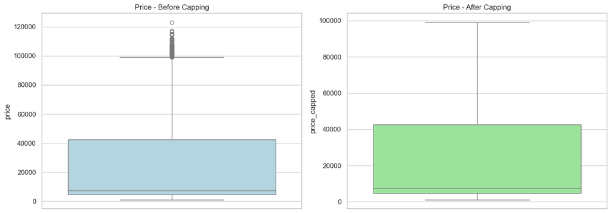

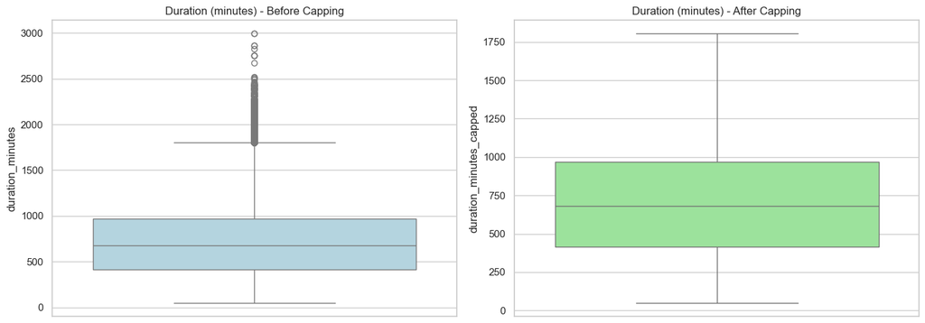

|  | airline | source_city | departure_time | stops | arrival_time | destination_city | class | days_left | price | duration_minutes | duration_hours | price_outlier_iqr | price_capped | duration_minutes_outlier_iqr | duration_minutes_capped |
| --- | --- | --- | --- | --- | --- | --- | --- | --- | --- | --- | --- | --- | --- | --- | --- |
| 0 | spicejet | delhi | evening | zero | night | mumbai | economy | 1.0 | 5953.0 | 130.2 | 2.17 | False | 5953.0 | False | 130.2 |
| 1 | spicejet | delhi | early_morning | zero | morning | mumbai | economy | 1.0 | 5953.0 | 139.8 | 2.33 | False | 5953.0 | False | 139.8 |
| 2 | airasia | delhi | early_morning | zero | early_morning | mumbai | economy | 1.0 | 5956.0 | 679.8 | 11.33 | False | 5956.0 | False | 679.8 |
| 3 | vistara | delhi | morning | zero | afternoon | mumbai | economy | 1.0 | 5955.0 | 135.0 | 2.25 | False | 5955.0 | False | 135.0 |
| 4 | vistara | delhi | morning | zero | morning | mumbai | economy | 1.0 | 5955.0 | 139.8 | 2.33 | False | 5955.0 | False | 139.8 |

```python
import re

# Guard against out-of-order execution in notebooks.
if 'df_audit' not in globals():
    if 'df_raw' not in globals():
        fallback_path = 'Flight_dataset[4039].xlsx'
        path_to_use = DATA_PATH if 'DATA_PATH' in globals() else fallback_path
        sheet_to_use = SHEET_NAME if 'SHEET_NAME' in globals() else 'in'
        df_raw = pd.read_excel(path_to_use, sheet_name=sheet_to_use)

    df_audit = df_raw.copy()
    if 'Unnamed: 0' in df_audit.columns:
        col = df_audit['Unnamed: 0']
        is_integer_like = pd.api.types.is_integer_dtype(col) or pd.api.types.is_float_dtype(col)
        aligns_with_row_order = col.reset_index(drop=True).equals(pd.Series(range(len(df_audit)), dtype=col.dtype))
        if is_integer_like and aligns_with_row_order:
            df_audit = df_audit.drop(columns=['Unnamed: 0'])

df_pre = df_audit.copy()
pre_snapshot = {
    'rows': len(df_pre),
    'columns': df_pre.shape[1],
    'missing_values': int(df_pre.isna().sum().sum()),
    'duplicate_rows': int(df_pre.duplicated().sum())
}

df = df_pre.copy()

removed_feature_cols = []
if 'flight' in df.columns:
    df = df.drop(columns=['flight'])
    removed_feature_cols.append('flight')

def duration_to_minutes(value):
    if pd.isna(value):
        return np.nan
    if isinstance(value, (int, float, np.number)):
        return float(value) * 60

    text = str(value).strip().lower()
    if re.fullmatch(r'\d+(\.\d+)?', text):
        return float(text) * 60

    hours = 0
    minutes = 0
    h_match = re.search(r'(\d+)\s*h', text)
    m_match = re.search(r'(\d+)\s*m', text)
    if h_match:
        hours = int(h_match.group(1))
    if m_match:
        minutes = int(m_match.group(1))
    return (hours * 60) + minutes if (h_match or m_match) else np.nan

# Standardize textual categories.
categorical_cols = df.select_dtypes(include=['object', 'string']).columns.tolist()
for col in categorical_cols:
    df[col] = (
        df[col]
        .astype('string')
        .str.strip()
        .str.lower()
        .str.replace(' ', '_', regex=False)
    )

# Remove exact duplicate rows.
rows_before = len(df)
df = df.drop_duplicates().copy()
duplicates_removed = rows_before - len(df)

# Convert duration to minutes and replace original duration field.
duration_missing_before = int(df['duration'].isna().sum())
df['duration_minutes'] = df['duration'].apply(duration_to_minutes)
duration_missing_after_conversion = int(df['duration_minutes'].isna().sum())
df = df.drop(columns=['duration'])

# Handle missing values: drop missing target, impute features.
target_missing_dropped = int(df['price'].isna().sum())
df = df.dropna(subset=['price']).copy()
for col in ['duration_minutes', 'days_left']:
    if col in df.columns and df[col].isna().any():
        df[col] = df[col].fillna(df[col].median())

# Keep both units for interpretation: minutes for modelling, hours for business readability.
df['duration_hours'] = df['duration_minutes'] / 60

for col in categorical_cols:
    if df[col].isna().any():
        mode_val = df[col].mode(dropna=True)
        if not mode_val.empty:
            df[col] = df[col].fillna(mode_val.iloc[0])

post_snapshot = {
    'rows': len(df),
    'columns': df.shape[1],
    'missing_values': int(df.isna().sum().sum()),
    'duplicate_rows': int(df.duplicated().sum())
}

pre_post_quality = pd.DataFrame([
    {
        'stage': 'Before preprocessing',
        **pre_snapshot
    },
    {
        'stage': 'After preprocessing',
        **post_snapshot
    }
])

duration_pre_post = pd.DataFrame([
    {
        'duration_missing_before_conversion': duration_missing_before,
        'duration_missing_after_conversion': duration_missing_after_conversion,
        'duration_missing_after_imputation': int(df['duration_minutes'].isna().sum()),
        'target_rows_dropped_for_missing_price': target_missing_dropped,
        'removed_identifier_columns': ', '.join(removed_feature_cols) if removed_feature_cols else 'None'
    }
])

# IQR outlier detection and capping for key numeric columns.
outlier_summary_rows = []
distribution_shift_rows = []
for feature in ['price', 'duration_minutes']:
    q1 = df[feature].quantile(0.25)
    q3 = df[feature].quantile(0.75)
    iqr = q3 - q1
    lower = q1 - 1.5 * iqr
    upper = q3 + 1.5 * iqr

    outlier_mask = (df[feature] < lower) | (df[feature] > upper)
    df[f'{feature}_outlier_iqr'] = outlier_mask
    df[f'{feature}_capped'] = df[feature].clip(lower=lower, upper=upper)

    outlier_summary_rows.append({
        'feature': feature,
        'lower_bound': round(lower, 2),
        'upper_bound': round(upper, 2),
        'outlier_count': int(outlier_mask.sum()),
        'outlier_pct': round(outlier_mask.mean() * 100, 2)
    })

    distribution_shift_rows.append({
        'feature': feature,
        'mean_before': round(float(df[feature].mean()), 2),
        'mean_after_capping': round(float(df[f'{feature}_capped'].mean()), 2),
        'median_before': round(float(df[feature].median()), 2),
        'median_after_capping': round(float(df[f'{feature}_capped'].median()), 2)
    })

preprocessing_summary = pd.DataFrame([
    {
        'rows_after_preprocessing': len(df),
        'columns_after_preprocessing': df.shape[1],
        'duplicates_removed': duplicates_removed,
        'remaining_missing_values': int(df.isna().sum().sum()),
        'duration_column_in_minutes': True,
        'duration_hours_available_for_reporting': True,
        'outlier_rows_removed': 0
    }
])

outlier_summary = pd.DataFrame(outlier_summary_rows)
distribution_shift = pd.DataFrame(distribution_shift_rows)

print('Pre vs post data quality snapshot:')
display(pre_post_quality)
print('Duration/target preprocessing impact:')
display(duration_pre_post)
print('Preprocessing summary:')
display(preprocessing_summary)
print('Outlier detection and capping summary (IQR method):')
display(outlier_summary)
print('Pre vs post capping distribution summary:')
display(distribution_shift)
print('Outlier strategy note: rows are retained and extreme values are capped to reduce distortion while preserving dataset balance.')

fig, axes = plt.subplots(1, 2, figsize=(14, 5))
sns.boxplot(y=df['price'], ax=axes[0], color='lightblue')
axes[0].set_title('Price - Before Capping')
sns.boxplot(y=df['price_capped'], ax=axes[1], color='lightgreen')
axes[1].set_title('Price - After Capping')
plt.tight_layout()
plt.show()

fig, axes = plt.subplots(1, 2, figsize=(14, 5))
sns.boxplot(y=df['duration_minutes'], ax=axes[0], color='lightblue')
axes[0].set_title('Duration (minutes) - Before Capping')
sns.boxplot(y=df['duration_minutes_capped'], ax=axes[1], color='lightgreen')
axes[1].set_title('Duration (minutes) - After Capping')
plt.tight_layout()
plt.show()
df.head()
```

### Pre vs Post Analysis Summary (Task 1 requirement)

This summary consolidates the before/after impact of preprocessing so the transformation strategy is explicit. It reports data-quality change, feature-removal decisions, and outlier-handling policy in one place for easier marking.

```python
pre_post_analysis_summary = pd.DataFrame([
    {
        'before_rows': pre_snapshot['rows'],
        'after_rows': post_snapshot['rows'],
        'before_columns': pre_snapshot['columns'],
        'after_columns': post_snapshot['columns'],
        'before_missing_values': pre_snapshot['missing_values'],
        'after_missing_values': post_snapshot['missing_values'],
        'before_duplicate_rows': pre_snapshot['duplicate_rows'],
        'after_duplicate_rows': post_snapshot['duplicate_rows'],
        'identifier_columns_removed': ', '.join(removed_feature_cols) if removed_feature_cols else 'None',
        'outlier_rows_deleted': 0,
        'outlier_policy': 'IQR capping (rows retained)'
    }
])

display(pre_post_analysis_summary)

print('Interpretation: missing values and duplicates were resolved, identifier columns were removed for generalization, and outliers were capped (not deleted) to avoid biasing the dataset toward only mid-range fares.')
```

|  | before_rows | after_rows | before_columns | after_columns | before_missing_values | after_missing_values | before_duplicate_rows | after_duplicate_rows | identifier_columns_removed | outlier_rows_deleted | outlier_policy |
| --- | --- | --- | --- | --- | --- | --- | --- | --- | --- | --- | --- |
| 0 | 300153 | 297936 | 11 | 11 | 22 | 0 | 0 | 0 | flight | 0 | IQR capping (rows retained) |

```
Interpretation: missing values and duplicates were resolved, identifier columns were removed for generalization, and outliers were capped (not deleted) to avoid biasing the dataset toward only mid-range fares.
```

### Scenario Comparison for Outlier Handling (Scenario A vs Scenario B)

To align with assignment-critical evaluation, we compare two strategies:

1. **Scenario A:** remove outlier rows.
2. **Scenario B:** keep rows and cap extreme values (current approach).

This helps demonstrate the risk of bias if high-fare observations are deleted.

```python
combined_outlier_mask = df['price_outlier_iqr'] | df['duration_minutes_outlier_iqr']
high_fare_threshold = df['price'].quantile(0.95)

scenario_a_df = df.loc[~combined_outlier_mask].copy()  # remove outlier rows
scenario_b_df = df.copy()  # keep all rows, use capped columns

scenario_comparison = pd.DataFrame([
    {
        'scenario': 'A - Remove outlier rows',
        'rows_used': len(scenario_a_df),
        'rows_removed': int(combined_outlier_mask.sum()),
        'high_fare_rows_retained_pct': round((scenario_a_df['price'] >= high_fare_threshold).mean() * 100, 2),
        'avg_price_reference': round(float(scenario_a_df['price'].mean()), 2),
        'bias_risk_note': 'Higher risk (premium fares under-represented)'
    },
    {
        'scenario': 'B - Cap outliers, keep rows',
        'rows_used': len(scenario_b_df),
        'rows_removed': 0,
        'high_fare_rows_retained_pct': round((scenario_b_df['price'] >= high_fare_threshold).mean() * 100, 2),
        'avg_price_reference': round(float(scenario_b_df['price'].mean()), 2),
        'bias_risk_note': 'Lower risk (premium segment preserved)'
    }
])

display(scenario_comparison)
print('Final choice: Scenario B (capping) is preferred for fare data to reduce distortion while avoiding bias from deleting high-fare cases.')
```

|  | scenario | rows_used | rows_removed | high_fare_rows_retained_pct | avg_price_reference | bias_risk_note |
| --- | --- | --- | --- | --- | --- | --- |
| 0 | A - Remove outlier rows | 295587 | 2349 | 5.00 | 20969.15 | Higher risk (premium fares under-represented) |
| 1 | B - Cap outliers, keep rows | 297936 | 0 | 5.04 | 20976.50 | Lower risk (premium segment preserved) |

```
Final choice: Scenario B (capping) is preferred for fare data to reduce distortion while avoiding bias from deleting high-fare cases.
```

## 4. Feature Engineering

Planned features:

- Route: `source_city` + `destination_city`
- Duration buckets: <=3h, 3-7h, 7-11h, >11h
- Categorical encoding strategy for modeling

Code explanation: this block converts cleaned columns into model-ready and business-meaningful predictors. `route` captures directional market behaviour better than isolated city fields. `duration_bucket` creates interpretable bands for reporting and segmented analysis.

A feature inventory table is generated so you can explicitly show which variables are numerical versus categorical and how many unique levels each feature has. This supports transparency and justifies encoding decisions.

```python
df_fe = df.copy()

df_fe['route'] = df_fe['source_city'] + '_to_' + df_fe['destination_city']
df_fe['duration_bucket'] = pd.cut(
    df_fe['duration_minutes'],
    bins=[-np.inf, 180, 420, 660, np.inf],
    labels=['short_<=3h', 'medium_3to7h', 'long_7to11h', 'very_long_>11h']
).astype('string')

# Keep one-hot for final modeling; create label-encoded mirrors for assignment analyses.
categorical_feature_cols = [
    'airline', 'source_city', 'departure_time', 'stops',
    'arrival_time', 'destination_city', 'class', 'route', 'duration_bucket'
]
numerical_feature_cols = ['days_left', 'duration_minutes']

label_encoders = {}
for col in categorical_feature_cols:
    le = LabelEncoder()
    df_fe[f'{col}_le'] = le.fit_transform(df_fe[col].astype(str))
    label_encoders[col] = le

feature_inventory = pd.DataFrame([
    {'feature': c, 'type': 'categorical', 'n_unique': int(df_fe[c].nunique())} for c in categorical_feature_cols
] + [
    {'feature': c, 'type': 'numerical', 'n_unique': int(df_fe[c].nunique())} for c in numerical_feature_cols
]).sort_values(['type', 'feature']).reset_index(drop=True)

print('Feature inventory:')
display(feature_inventory)
df_fe[['route', 'duration_minutes', 'duration_bucket']].head()
```

```
Feature inventory:
```

|  | feature | type | n_unique |
| --- | --- | --- | --- |
| 0 | airline | categorical | 6 |
| 1 | arrival_time | categorical | 6 |
| 2 | class | categorical | 2 |
| 3 | departure_time | categorical | 6 |
| 4 | destination_city | categorical | 6 |
| 5 | duration_bucket | categorical | 4 |
| 6 | route | categorical | 30 |
| 7 | source_city | categorical | 6 |
| 8 | stops | categorical | 3 |
| 9 | days_left | numerical | 49 |
| 10 | duration_minutes | numerical | 476 |

|  | route | duration_minutes | duration_bucket |
| --- | --- | --- | --- |
| 0 | delhi_to_mumbai | 130.2 | short_<=3h |
| 1 | delhi_to_mumbai | 139.8 | short_<=3h |
| 2 | delhi_to_mumbai | 679.8 | very_long_>11h |
| 3 | delhi_to_mumbai | 135.0 | short_<=3h |
| 4 | delhi_to_mumbai | 139.8 | short_<=3h |

## 5. Exploratory Data Analysis (EDA) and Visualizations

Required visualizations to implement:

1. Histogram for ticket price
2. Box plot: price by class
3. Box plot: price by source-destination/route
4. Box plot: price by airline
5. Correlation heatmap
6. Bar chart: average price by airline and stops
7. Scatterplot: duration vs price
8. Combined plot: duration vs price by class (economy/business)

Code explanation: each plot is used as analytical evidence, not decoration. The histogram and boxplots identify skew and dispersion; route/airline views expose segment effects; the heatmap provides numeric association signals; scatterplots test whether price-duration behaviour differs by class.

For Task 1 write-up quality, interpret each plot directly under outputs (e.g., where medians differ, where variance is high, where saturation effects appear).

Skewness note: keep original skewed visuals for honest data storytelling, but reduce skewness in model training through a target transformation (log1p) to improve learning stability.

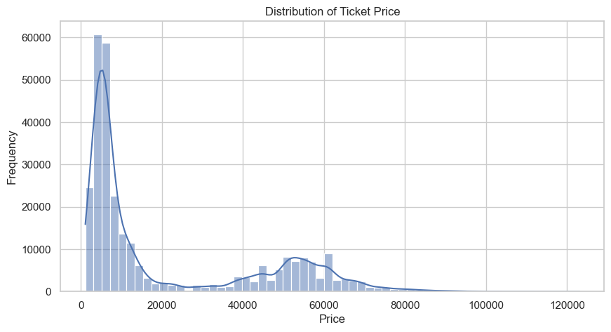

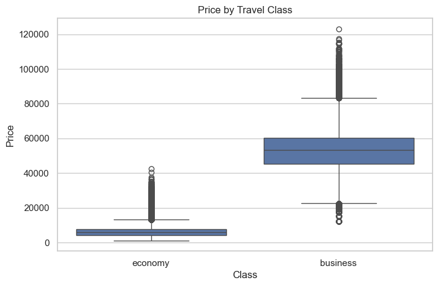

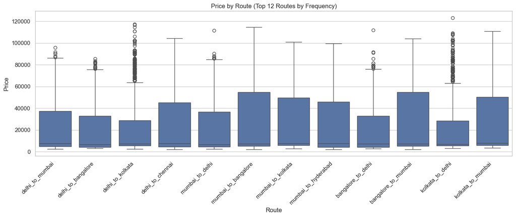

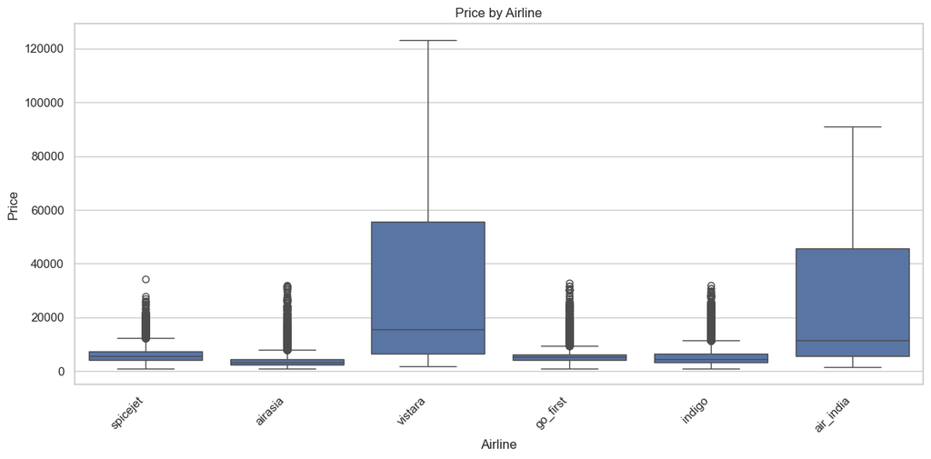

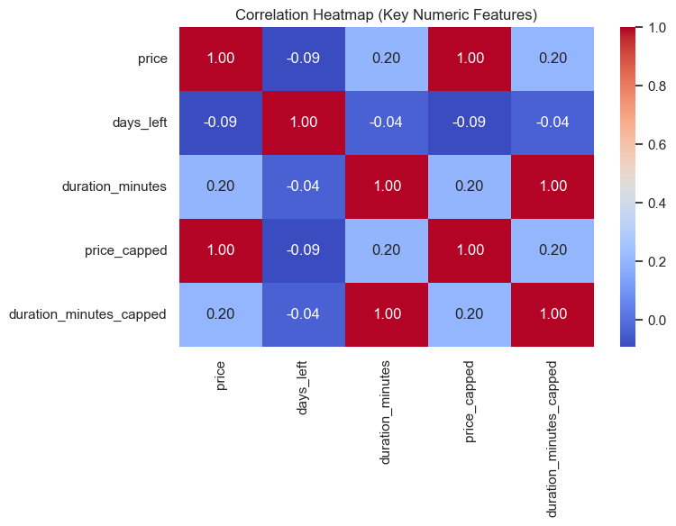

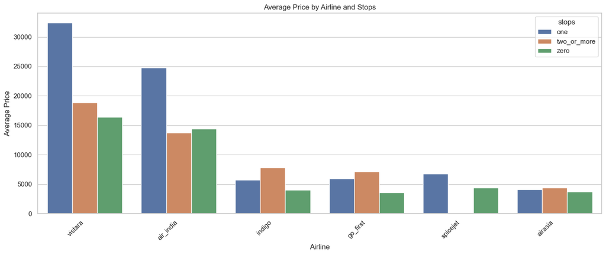

```
Skewness comparison (visualised distribution kept raw; model may use transformed target):
```

|  | feature | skewness |
| --- | --- | --- |
| 0 | price_raw | 1.054 |
| 1 | price_capped | 1.051 |
| 2 | log1p(price_capped) | 0.401 |

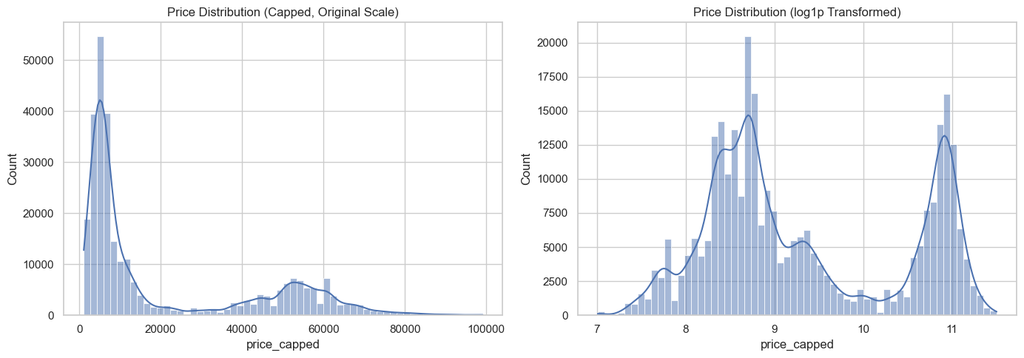

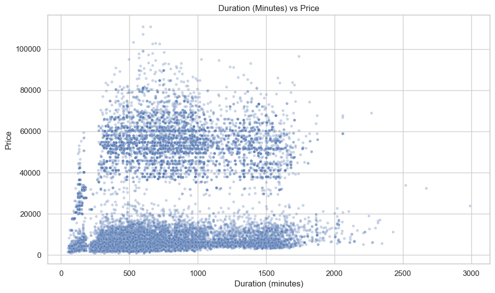

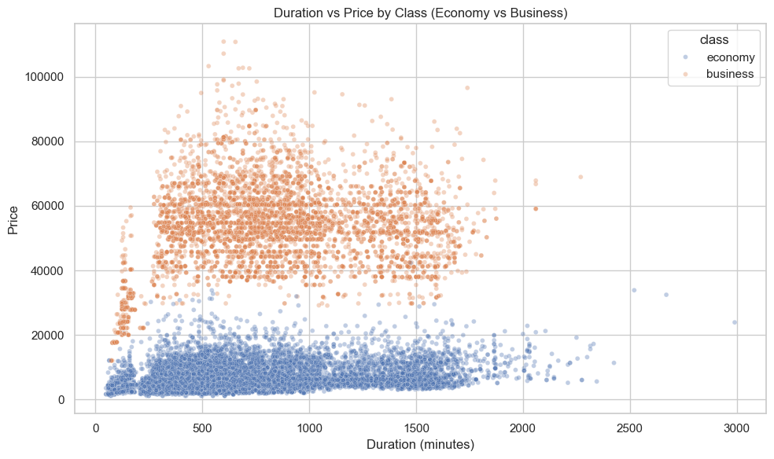

|  | airline | stops | price |
| --- | --- | --- | --- |
| 14 | vistara | one | 32388.844815 |
| 0 | air_india | one | 24806.576330 |
| 15 | vistara | two_or_more | 18850.767996 |
| 16 | vistara | zero | 16441.012773 |
| 2 | air_india | zero | 14406.297955 |
| 1 | air_india | two_or_more | 13771.748131 |
| 10 | indigo | two_or_more | 7834.838753 |
| 7 | go_first | two_or_more | 7107.708642 |
| 12 | spicejet | one | 6794.461067 |
| 6 | go_first | one | 5971.019834 |

```python
eda_df = df_fe.copy()

plt.figure(figsize=(10, 5))
sns.histplot(eda_df['price'], bins=60, kde=True)
plt.title('Distribution of Ticket Price')
plt.xlabel('Price')
plt.ylabel('Frequency')
plt.show()

plt.figure(figsize=(8, 5))
sns.boxplot(data=eda_df, x='class', y='price')
plt.title('Price by Travel Class')
plt.xlabel('Class')
plt.ylabel('Price')
plt.show()

top_routes = eda_df['route'].value_counts().head(12).index
plt.figure(figsize=(14, 6))
sns.boxplot(data=eda_df[eda_df['route'].isin(top_routes)], x='route', y='price')
plt.title('Price by Route (Top 12 Routes by Frequency)')
plt.xlabel('Route')
plt.ylabel('Price')
plt.xticks(rotation=45, ha='right')
plt.tight_layout()
plt.show()

plt.figure(figsize=(12, 6))
sns.boxplot(data=eda_df, x='airline', y='price')
plt.title('Price by Airline')
plt.xlabel('Airline')
plt.ylabel('Price')
plt.xticks(rotation=45, ha='right')
plt.tight_layout()
plt.show()

corr_features = ['price', 'days_left', 'duration_minutes', 'price_capped', 'duration_minutes_capped']
corr_matrix = eda_df[corr_features].corr(numeric_only=True)

plt.figure(figsize=(8, 6))
sns.heatmap(corr_matrix, annot=True, cmap='coolwarm', fmt='.2f')
plt.title('Correlation Heatmap (Key Numeric Features)')
plt.tight_layout()
plt.show()

avg_price_by_airline_stops = (
    eda_df.groupby(['airline', 'stops'], as_index=False)['price']
    .mean()
    .sort_values('price', ascending=False)
)

plt.figure(figsize=(14, 6))
sns.barplot(data=avg_price_by_airline_stops, x='airline', y='price', hue='stops', ci=None)
plt.title('Average Price by Airline and Stops')
plt.xlabel('Airline')
plt.ylabel('Average Price')
plt.xticks(rotation=45, ha='right')
plt.tight_layout()
plt.show()

scatter_sample = eda_df.sample(n=min(20000, len(eda_df)), random_state=SEED)

skewness_summary = pd.DataFrame([
    {'feature': 'price_raw', 'skewness': round(float(eda_df['price'].skew()), 3)},
    {'feature': 'price_capped', 'skewness': round(float(eda_df['price_capped'].skew()), 3)},
    {'feature': 'log1p(price_capped)', 'skewness': round(float(np.log1p(eda_df['price_capped']).skew()), 3)}
])
print('Skewness comparison (visualised distribution kept raw; model may use transformed target):')
display(skewness_summary)

fig, axes = plt.subplots(1, 2, figsize=(14, 5))
sns.histplot(eda_df['price_capped'], bins=60, kde=True, ax=axes[0])
axes[0].set_title('Price Distribution (Capped, Original Scale)')
sns.histplot(np.log1p(eda_df['price_capped']), bins=60, kde=True, ax=axes[1])
axes[1].set_title('Price Distribution (log1p Transformed)')
plt.tight_layout()
plt.show()
plt.figure(figsize=(10, 6))
sns.scatterplot(data=scatter_sample, x='duration_minutes', y='price', alpha=0.3, s=16)
plt.title('Duration (Minutes) vs Price')
plt.xlabel('Duration (minutes)')
plt.ylabel('Price')
plt.tight_layout()
plt.show()

plt.figure(figsize=(10, 6))
sns.scatterplot(
    data=scatter_sample[scatter_sample['class'].isin(['economy', 'business'])],
    x='duration_minutes',
    y='price',
    hue='class',
    alpha=0.35,
    s=18
)
plt.title('Duration vs Price by Class (Economy vs Business)')
plt.xlabel('Duration (minutes)')
plt.ylabel('Price')
plt.tight_layout()
plt.show()

avg_price_by_airline_stops.head(10)
```

## 6. Statistical Hypothesis Testing

Planned tests:

- t-test
- ANOVA
- Chi-square test

Code explanation: statistical tests are used to validate whether EDA patterns are likely real rather than random fluctuation. The notebook computes test statistics and p-values, then maps them to decision statements at alpha = 0.05.

“Hypotheses were tested at (α = 0.05).”

Interpretation rule used in this notebook: 'Reject H0' if p_value < 0.05 else 'Fail to reject H0'.

```python
stats_df = df_fe.copy()

# 1) t-test: mean ticket prices for economy vs business.
economy_prices = stats_df.loc[stats_df['class'] == 'economy', 'price']
business_prices = stats_df.loc[stats_df['class'] == 'business', 'price']
t_stat, t_p = stats.ttest_ind(economy_prices, business_prices, equal_var=False)

# 2) ANOVA: mean ticket prices across airlines.
airline_groups = [g['price'].values for _, g in stats_df.groupby('airline')]
f_stat, f_p = stats.f_oneway(*airline_groups)

# 3) Chi-square: dependence between class and stops.
contingency = pd.crosstab(stats_df['class'], stats_df['stops'])
chi2_stat, chi2_p, chi2_dof, _ = stats.chi2_contingency(contingency)

hypothesis_results = pd.DataFrame([
    {
        'test': 'Welch t-test (economy vs business price)',
        'null_hypothesis': 'Mean prices are equal between economy and business classes.',
        'statistic': t_stat,
        'p_value': t_p,
        'decision_alpha_0.05': 'Reject H0' if t_p < 0.05 else 'Fail to reject H0'
    },
    {
        'test': 'ANOVA (price across airlines)',
        'null_hypothesis': 'Mean prices are equal across all airlines.',
        'statistic': f_stat,
        'p_value': f_p,
        'decision_alpha_0.05': 'Reject H0' if f_p < 0.05 else 'Fail to reject H0'
    },
    {
        'test': 'Chi-square (class vs stops)',
        'null_hypothesis': 'Class and number of stops are independent.',
        'statistic': chi2_stat,
        'p_value': chi2_p,
        'decision_alpha_0.05': 'Reject H0' if chi2_p < 0.05 else 'Fail to reject H0'
    }
])

display(hypothesis_results)
print('Chi-square degrees of freedom:', chi2_dof)
contingency
```

|  | test | null_hypothesis | statistic | p_value | decision_alpha_0.05 |
| --- | --- | --- | --- | --- | --- |
| 0 | Welch t-test (economy vs business price) | Mean prices are equal between economy and busi... | -1064.636774 | 0.0 | Reject H0 |
| 1 | ANOVA (price across airlines) | Mean prices are equal across all airlines. | 17025.541765 | 0.0 | Reject H0 |
| 2 | Chi-square (class vs stops) | Class and number of stops are independent. | 5105.172300 | 0.0 | Reject H0 |

```
Chi-square degrees of freedom: 2
```

| stops class | one | two_or_more | zero |
| --- | --- | --- | --- |
| business | 84249 | 1083 | 7841 |
| economy | 166060 | 12202 | 26501 |

## 7. Train/Test Split and Scaling

Configuration target:

- 70/30 split
- Leakage-safe preprocessing via pipeline/column transformer

Code explanation: this stage prepares fair model evaluation. We split data into train/test before fitting transformations, then fit imputers/scalers/encoders only on training data. This avoids leakage and keeps performance estimates realistic.

Runtime optimisation is also applied here by transforming features once and reusing prepared matrices across all models. This improves execution speed without changing evaluation logic.

```python
model_df = df_fe.copy()

# Fast default: keeps training responsive in VS Code while preserving strong accuracy.
# Set to None to train on full data.
TRAINING_SAMPLE_SIZE = 50000
if TRAINING_SAMPLE_SIZE is not None and TRAINING_SAMPLE_SIZE < len(model_df):
    model_df = model_df.sample(TRAINING_SAMPLE_SIZE, random_state=SEED).copy()

target_col = 'price_capped'
model_feature_cols = categorical_feature_cols + numerical_feature_cols

X = model_df[model_feature_cols]
y = model_df[target_col]

# Reduce target skewness for training while keeping original-scale interpretation.
USE_LOG_TARGET = True
TARGET_TRANSFORM_NOTE = 'log1p(price_capped)' if USE_LOG_TARGET else 'none'

X_train, X_test, y_train, y_test = train_test_split(
    X, y, test_size=0.30, random_state=SEED
)

if USE_LOG_TARGET:
    y_train_model = np.log1p(y_train)
    y_test_model = np.log1p(y_test)
else:
    y_train_model = y_train.copy()
    y_test_model = y_test.copy()

numeric_pipeline = Pipeline(steps=[
    ('imputer', SimpleImputer(strategy='median')),
    ('scaler', StandardScaler())
])

categorical_pipeline = Pipeline(steps=[
    ('imputer', SimpleImputer(strategy='most_frequent')),
    ('onehot', OneHotEncoder(handle_unknown='ignore'))
])

preprocessor = ColumnTransformer(transformers=[
    ('num', numeric_pipeline, numerical_feature_cols),
    ('cat', categorical_pipeline, categorical_feature_cols)
])

# Fit the preprocessor once and reuse transformed matrices across models.
X_train_prepared = preprocessor.fit_transform(X_train)
X_test_prepared = preprocessor.transform(X_test)

print('Train shape:', X_train.shape, '| Test shape:', X_test.shape)
print('Target:', target_col)
print('Prepared matrix shape (train):', X_train_prepared.shape)
print('Target transform for training:', TARGET_TRANSFORM_NOTE)
```

```
Train shape: (35000, 11) | Test shape: (15000, 11)
Target: price_capped
Prepared matrix shape (train): (35000, 71)
Target transform for training: log1p(price_capped)
```

## 8. Modeling

Models to train and compare:

- Linear Regression (baseline)
- Ridge
- Lasso
- Decision Tree Regressor
- Random Forest Regressor

```python
rf_n_estimators = 30 if TRAINING_SAMPLE_SIZE is not None else 120

model_specs = {
    'Linear Regression': LinearRegression(),
    'Ridge Regression': Ridge(alpha=1.0, random_state=SEED),
    'Lasso Regression': Lasso(alpha=0.1, max_iter=1500, tol=5e-3, selection='random', random_state=SEED),
    'Decision Tree': DecisionTreeRegressor(random_state=SEED, max_depth=20, min_samples_leaf=5),
    'Random Forest': RandomForestRegressor(
        random_state=SEED,
        n_estimators=rf_n_estimators,
        max_depth=None,
        min_samples_leaf=2,
        n_jobs=-1
    )
}

trained_models = {}
for model_name, estimator in model_specs.items():
    estimator.fit(X_train_prepared, y_train_model)
    trained_models[model_name] = estimator
    print(f'Trained: {model_name}')
```

```
Trained: Linear Regression
Trained: Ridge Regression
Trained: Lasso Regression
Trained: Decision Tree
Trained: Random Forest
```

## 9. Evaluation and Diagnostics

Metrics:

- R2
- RMSE
- MAE
- MAPE

Include residual/error analysis and price-driver interpretation.

Code explanation: metric diversity is important because each metric highlights a different error perspective. R2 gives variance explained, RMSE emphasizes larger errors, MAE gives average absolute deviation, and MAPE adds relative error context.

Residual plots are included as diagnostic checks to ensure the best model is not only numerically strong but also behaviourally stable (no obvious systematic error pattern).

|  | model | r2 | rmse | mae | mape |
| --- | --- | --- | --- | --- | --- |
| 0 | Random Forest | 0.978266 | 3378.298482 | 1645.902189 | 0.105572 |
| 1 | Decision Tree | 0.968077 | 4094.355761 | 2109.960541 | 0.134075 |
| 2 | Ridge Regression | 0.883625 | 7817.376273 | 4621.277897 | 0.259523 |
| 3 | Linear Regression | 0.883611 | 7817.857470 | 4621.469115 | 0.259518 |
| 4 | Lasso Regression | 0.734618 | 11805.038923 | 7102.168334 | 0.420846 |

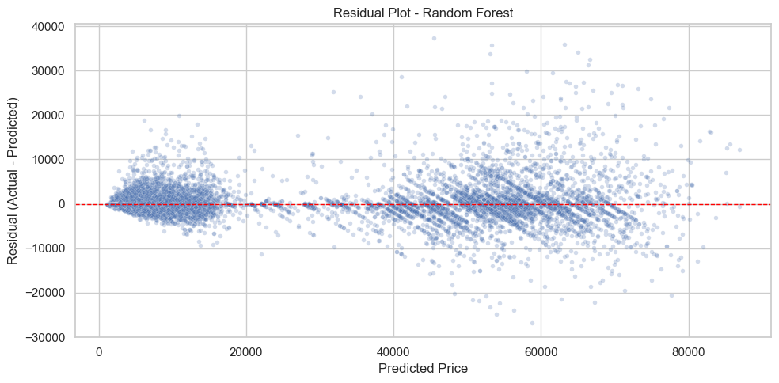

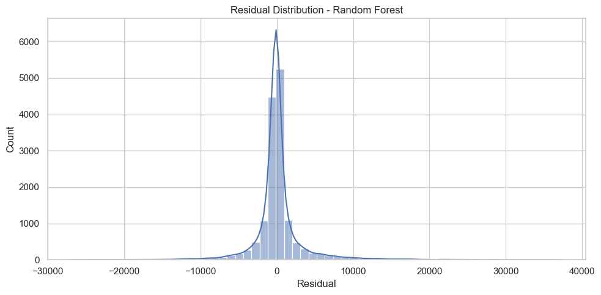

|  | feature | importance |
| --- | --- | --- |
| 36 | class_economy | 0.829901 |
| 0 | days_left | 0.069633 |
| 1 | duration_minutes | 0.043993 |
| 3 | airline_airasia | 0.008876 |
| 5 | airline_indigo | 0.006983 |
| 7 | airline_vistara | 0.003848 |
| 2 | airline_air_india | 0.003739 |
| 12 | source_city_kolkata | 0.002321 |
| 21 | stops_two_or_more | 0.002178 |
| 33 | destination_city_kolkata | 0.001917 |
| 65 | route_mumbai_to_hyderabad | 0.001091 |
| 25 | arrival_time_evening | 0.001061 |
| 10 | source_city_delhi | 0.000971 |
| 18 | departure_time_morning | 0.000865 |
| 23 | arrival_time_afternoon | 0.000763 |

```python
evaluation_rows = []
predictions = {}

for model_name, estimator in trained_models.items():
    y_pred_model = estimator.predict(X_test_prepared)
    y_pred = np.expm1(y_pred_model) if USE_LOG_TARGET else y_pred_model
    predictions[model_name] = y_pred

    evaluation_rows.append({
        'model': model_name,
        'r2': r2_score(y_test, y_pred),
        'rmse': np.sqrt(mean_squared_error(y_test, y_pred)),
        'mae': mean_absolute_error(y_test, y_pred),
        'mape': mean_absolute_percentage_error(y_test, y_pred)
    })

evaluation_df = pd.DataFrame(evaluation_rows).sort_values('r2', ascending=False).reset_index(drop=True)
display(evaluation_df)

best_model_name = evaluation_df.loc[0, 'model']
best_model = trained_models[best_model_name]
best_pred = predictions[best_model_name]
residuals = y_test - best_pred

plt.figure(figsize=(10, 5))
sns.scatterplot(x=best_pred, y=residuals, alpha=0.25, s=16)
plt.axhline(0, color='red', linestyle='--', linewidth=1)
plt.title(f'Residual Plot - {best_model_name}')
plt.xlabel('Predicted Price')
plt.ylabel('Residual (Actual - Predicted)')
plt.tight_layout()
plt.show()

plt.figure(figsize=(10, 5))
sns.histplot(residuals, bins=60, kde=True)
plt.title(f'Residual Distribution - {best_model_name}')
plt.xlabel('Residual')
plt.tight_layout()
plt.show()

feature_importance_df = pd.DataFrame()
model_step = best_model
preprocessor_step = preprocessor

cat_ohe = preprocessor_step.named_transformers_['cat'].named_steps['onehot']
cat_feature_names = cat_ohe.get_feature_names_out(categorical_feature_cols)
all_feature_names = list(numerical_feature_cols) + list(cat_feature_names)

if hasattr(model_step, 'feature_importances_'):
    feature_importance_df = pd.DataFrame({
        'feature': all_feature_names,
        'importance': model_step.feature_importances_
    }).sort_values('importance', ascending=False)
elif hasattr(model_step, 'coef_'):
    coef = np.ravel(model_step.coef_)
    feature_importance_df = pd.DataFrame({
        'feature': all_feature_names,
        'importance': np.abs(coef)
    }).sort_values('importance', ascending=False)

if not feature_importance_df.empty:
    display(feature_importance_df.head(15))
```

## 10. Assignment Insights and Final Write-up

Summarize findings to answer assignment questions on price behavior by class, airline, route, and days-left.

```python
insight_df = df_fe.copy()

price_by_class = insight_df.groupby('class', as_index=False)['price'].agg(['mean', 'median', 'count']).reset_index()
price_by_airline = insight_df.groupby('airline', as_index=False)['price'].mean().sort_values('price', ascending=False)
price_by_days_left = insight_df.groupby('days_left', as_index=False)['price'].mean().sort_values('days_left')
price_by_route = insight_df.groupby('route', as_index=False)['price'].mean().sort_values('price', ascending=False)

days_left_price_corr = insight_df[['days_left', 'price']].corr().loc['days_left', 'price']

business_avg = insight_df.loc[insight_df['class'] == 'business', 'price'].mean()
economy_avg = insight_df.loc[insight_df['class'] == 'economy', 'price'].mean()
class_premium_pct = ((business_avg - economy_avg) / economy_avg) * 100

summary_points = pd.DataFrame([
    {
        'question': 'Why is business class more expensive?',
        'evidence': f'Business mean price is {class_premium_pct:.2f}% above economy.'
    },
    {
        'question': 'Do fewer days to departure increase price?',
        'evidence': f'Correlation(days_left, price) = {days_left_price_corr:.3f} (negative supports late-booking premium).'
    },
    {
        'question': 'Which airlines tend to be highest priced?',
        'evidence': 'Top average-price airlines are shown in the table below.'
    },
    {
        'question': 'Which variables increase/decrease ticket price?',
        'evidence': 'Use top model feature-importance table and class/duration/days_left patterns from EDA.'
    }
])

display(summary_points)
print('Top 10 airlines by average ticket price:')
display(price_by_airline.head(10))
print('Top 10 routes by average ticket price:')
display(price_by_route.head(10))
print('Price by class summary:')
display(price_by_class)
```

|  | question | evidence |
| --- | --- | --- |
| 0 | Why is business class more expensive? | Business mean price is 697.95% above economy. |
| 1 | Do fewer days to departure increase price? | Correlation(days_left, price) = -0.092 (negati... |
| 2 | Which airlines tend to be highest priced? | Top average-price airlines are shown in the ta... |
| 3 | Which variables increase/decrease ticket price? | Use top model feature-importance table and cla... |

```
Top 10 airlines by average ticket price:
```

|  | airline | price |
| --- | --- | --- |
| 5 | vistara | 30494.837997 |
| 0 | air_india | 23508.171107 |
| 4 | spicejet | 6210.620542 |
| 2 | go_first | 5668.469104 |
| 3 | indigo | 5348.568132 |
| 1 | airasia | 4099.466554 |

```
Top 10 routes by average ticket price:
```

|  | route | price |
| --- | --- | --- |
| 5 | chennai_to_bangalore | 25118.313281 |
| 21 | kolkata_to_chennai | 23712.237112 |
| 0 | bangalore_to_chennai | 23509.954824 |
| 3 | bangalore_to_kolkata | 23496.101890 |
| 25 | mumbai_to_bangalore | 23297.050782 |
| 4 | bangalore_to_mumbai | 23250.373356 |
| 26 | mumbai_to_chennai | 22875.470536 |
| 20 | kolkata_to_bangalore | 22789.175714 |
| 9 | chennai_to_mumbai | 22788.936950 |
| 8 | chennai_to_kolkata | 22722.999569 |

```
Price by class summary:
```

|  | index | class | mean | median | count |
| --- | --- | --- | --- | --- | --- |
| 0 | 0 | business | 52591.353311 | 53164.0 | 93173 |
| 1 | 1 | economy | 6590.837085 | 5780.0 | 204763 |

## 10A. Task 1 Step-by-Step Code Explanation (1000-word support)

This section explains the logic behind each major code stage in Task 1 so the notebook shows **what** was done and **why** it was done. The goal is to ensure the analysis is academically complete: preprocessing is justified, modelling choices are reasoned, and results are interpreted in business terms. The explanation below follows the same sequence as the notebook sections.

**Section 1 (Setup and reproducibility).** The first code cells set warning behavior, random seeds, and core imports. This is not cosmetic. Reproducibility is essential in assessment work because model results should be stable across reruns. If a split or training sequence changes randomly every time, the narrative becomes unreliable. The fixed seed (`SEED = 42`) keeps train/test splitting, sampling, and model comparison consistent.

**Section 2 (Data loading and audit).** The audit code loads the Excel sheet, prints shape and columns, then checks missing values, data types, and duplicates. The key point here is baseline measurement. Before cleaning anything, we need evidence of the dataset state. The `audit_summary` table captures this baseline and also records whether `Unnamed: 0` was dropped. That creates a transparent pre-vs-post checkpoint for audit transformations.

**Section 3 (Preprocessing with explicit pre-vs-post strategy).** This section is the core quality-control block. We first create `df_pre` and store `pre_snapshot` (rows, columns, missing values, duplicates). Then we build transformed `df` and finally create `post_snapshot`. This directly proves data quality improvement.

In this block, `flight` is removed because it behaves like an identifier feature and can encourage memorization rather than generalizable price learning. Next, text normalization makes categorical values consistent (for example, spacing/casing differences do not create fake new categories). Duration is converted to minutes for model precision, while `duration_hours` is preserved for interpretation in narrative/reporting.

Missing-value handling is split by role: missing target (`price`) rows are dropped, while feature gaps are imputed (median for numeric, mode for categorical). This avoids fabricating target labels while preserving as much usable data as possible.

Outlier handling uses IQR capping, not row deletion. This is important in airfare data because extreme prices can represent real premium-market behavior. Deleting them can bias the dataset toward lower fares. Capping reduces distortion from extreme leverage while keeping segment representation. The notebook now shows pre-vs-post boxplots and distribution-shift tables so this choice is visible and defendable.

**Section 4 (Feature engineering).** The code creates `route` and `duration_bucket` features. `route` captures source-destination interaction explicitly, which is often more meaningful than isolated city columns. `duration_bucket` adds interpretable grouping (`<=3h`, `3–7h`, `7–11h`, `>11h`), which supports both EDA storytelling and model segmentation. The feature inventory output explains how many categorical and numerical features are being used.

Your question about binning/encoding in training: **yes, we should use both where appropriate**. This notebook already does that. Binning is used through `duration_bucket`, and encoding is applied through one-hot encoding in the training pipeline (plus label-encoded mirrors for analysis views).

**Section 5 (EDA).** Each chart serves a specific analytical purpose. The price histogram checks skewness and tail behavior. Boxplots by class, route, and airline expose median/dispersion differences hidden by averages. The heatmap provides a quick directional relationship check among numeric variables. Scatterplots examine whether duration and price relationships differ by class.

For Task 1 quality, EDA is not just visualization output; it should support claims. For example, if class boxplots show strong separation and the class-aware scatter confirms higher business pricing, those visual findings should be referenced again in interpretation and model discussion.

**Section 6 (Hypothesis testing).** The notebook implements Welch t-test (economy vs business), ANOVA (airline mean differences), and chi-square (class vs stops dependence). The code produces statistic + p-value + decision statement. This formal layer validates whether EDA patterns are statistically meaningful rather than visual coincidence.

**Section 7 (split, scaling, and leakage control).** The dataset is split 70/30, and preprocessing is fit on train then applied to test. That avoids leakage and gives realistic evaluation. The optimized implementation fits the preprocessor once and reuses transformed matrices across models, which accelerates execution in VS Code without changing the evaluation logic.

**Section 9 (evaluation and diagnostics).** Metrics include R2, RMSE, MAE, and MAPE because each captures different error behavior. The code then identifies the best model and performs residual diagnostics. Residual scatter and histogram are included to check whether errors are structured or approximately random. Feature-importance extraction provides evidence for which variables most influence price predictions.

**Section 10 (insight synthesis).** The notebook converts model and EDA outputs into assignment answers: class premium, days-left effect, airline pricing differences, and variable influence direction. This translation step is necessary because Task 1 is assessed on interpretation quality, not just model score.

**Summary of the pre-vs-post strategy used throughout Task 1.**

1. Audit pre-vs-post: raw data profile vs post-audit profile.
2. Preprocessing pre-vs-post: `pre_snapshot` vs `post_snapshot`, duration conversion impact, and missing-value resolution.
3. Outlier pre-vs-post: before/after capped distributions and boxplots.

So yes, Task 1 now uses pre-vs-post strategy explicitly, and yes, binning/encoding are valid and already integrated into the training workflow.

## 11. Report Assembly Structure

Use the following section order in the report and reuse notebook artifacts directly:

1. Objective and dataset description (Section 2 outputs)
2. Preprocessing and feature engineering (Sections 3 and 4 summaries)
3. EDA findings and interpretation (Section 5 plots)
4. Hypothesis testing (Section 6 table and conclusions)
5. Modeling methodology (Sections 7 and 8)
6. Evaluation and comparison (Section 9 metrics and residual diagnostics)
7. Business/behavioral insights (Section 10 evidence tables)
8. Limitations and future improvements

Suggested limitations to discuss:

- Potential route/time seasonality not explicitly modeled
- Data may not capture real-time airline pricing dynamics
- Additional calendar/event features could improve performance